# Ecoli_Prot_RNAseq_UMAP_Clust_210214

## Integrative Clustering of RNA-Seq and LC-MS-Based Proteomic Data

The data is taken from the [article by Hultqvist *et al*](https://www.nature.com/articles/s41559-018-0568-5) in Nature Ecology & Evolution.

```python
import os
import pandas as pd
import numpy as np
import matplotlib.pyplot as plt
import seaborn as sns
from scipy import stats
from sklearn.cluster import AgglomerativeClustering, MeanShift, DBSCAN
from sklearn.neighbors import kneighbors_graph
import umap


sns.set(font_scale = 1.2)
sns.set_style('whitegrid')
sns.set_palette('muted')
```

```python
def add_group_averages(df, groups):
    df = df.copy()
    for g in groups:
        group = np.array(df[groups[g]])
        averages = np.nanmean(group, axis=1)
        df[('Avg'+g)] = averages
    return df

def clustering_agglo(df, n_clusters):
    X = df.to_numpy()
    connectivity = kneighbors_graph(X, int(len(df.index)/10), include_self=False)
    agc = AgglomerativeClustering(linkage='ward',
                                  connectivity=connectivity,
                                  n_clusters=n_clusters)
    agc.fit(X)
    print('Found clusters', len(np.unique(agc.labels_)))

    return agc.labels_

def clustering_dbscan(df, eps, min_samples):
    X = df.to_numpy()
    dbs = DBSCAN(eps=eps, min_samples=min_samples)
    dbs.fit(X)
    print('Found clusters', len(np.unique(dbs.labels_)))

    return dbs.labels_

def clustering_meanshift(df, bandwidth):
    X = df.to_numpy()
    ms = MeanShift(bandwidth=bandwidth, cluster_all=True)
    ms.fit(X)
    print('Found clusters', len(np.unique(ms.labels_)))

    return ms.labels_

def get_gene_name(descr):
    try:
        gn = descr.split('GN=')[1]
        gn = gn.split(' ')[0]
    except:
        gn = ''
    return gn

def plot_heatmap(inDF, labels, title):
    df = inDF.copy()
    df['cluster'] = labels
    df.sort_values(by='cluster', inplace=True)
    plt.figure(figsize=(8,12))
    sns.heatmap(df.iloc[:,:-1], vmin=-2, vmax=2, center=0, cmap='coolwarm', cbar=True)
    plt.title(title, fontsize = 18)
    return df

def rename_prot_columns(inDF, inNames):
    mutate_names = lambda cn: 'P' + cn.split('/')[0][1:]
    renameDict = { cn: mutate_names(cn) for cn in inNames }
    return inDF.rename(columns=renameDict)

def rename_ratios(dfIn):
    renaming_dict = {}
    for c in dfIn.columns:
        if 'Abundances Normalized' in c:
            new_name = c.split(' ')[-1]
            new_name = 'Norm_' + new_name
            renaming_dict[c] = new_name
        elif 'Abundance ' in c:
            new_name = c.split(' ')[-1]
            renaming_dict[c] = new_name
    dfOut = dfIn.rename(renaming_dict,axis='columns')
    return dfOut

def rename_ratios2(dfIn):
    '''Adapted for Peptide Groups table'''
    renaming_dict = {}
    for c in dfIn.columns:
        if 'Abundance Ratio' in c:
            new_name = c.split(' ')[-3] + '/' + c.split(' ')[-1]
            renaming_dict[c] = new_name
        elif 'Abundances Grouped' in c:
            new_name = c.split(' ')[-1]
            renaming_dict[c] = new_name
        renaming_dict['Master Protein Accessions'] = 'Accession'
    dfOut = dfIn.rename(renaming_dict,axis='columns')
    return dfOut
```

### Import and clean up the protein data

The LC-MS data was processed using the vendor software that produces a bunch of tab-delimited text files. [The LC-MS data is available](https://www.ebi.ac.uk/pride/archive/projects/PXD005236) through the ProteomeXChange repository. You can find the Proteins file in the Github repo.

```python
dfProt = pd.read_csv(
    os.getcwd() + '/Prot_Data/Ecoli_MS_NormTotal_Fusion_160519_70_77_Proteins.txt',
    sep='\t'
)
print(dfProt.shape)
dfProt= rename_ratios2(dfProt)
dfProt.head(3)
```

```
(1955, 48)
```

|  | Proteins Unique Sequence ID | Checked | Protein FDR Confidence Combined | Master | Accession | Description | Exp q-value Combined | Sum PEP Score | Coverage in Percent | Number of Peptides | ... | Found in Sample in S5 F1 128C Sample S03_ORF | Found in Sample in S6 F1 129N Sample S04_ORF | Found in Sample in S9 F1 130C Sample S05_ORF_IPTG | Found in Sample in S8 F1 130N Sample S06_ORF_IPTG | Found in Sample in S10 F1 131 Sample S07_SVI | Found in Sample in S7 F1 129C Sample S08_SVI | Found in Sample in S3 F1 127C Sample S09_SVI_IPTG | Found in Sample in S4 F1 128N Sample S10_SVI_IPTG | Number of Protein Groups | Modifications |
| --- | --- | --- | --- | --- | --- | --- | --- | --- | --- | --- | --- | --- | --- | --- | --- | --- | --- | --- | --- | --- | --- |
| 0 | -9221854764723615317 | False | High | IsMasterProtein | P0AE52 | Putative peroxiredoxin bcp OS=Escherichia coli... | 0.0 | 18.206 | 38 | 6 | ... | High | High | High | High | High | High | High | High | 1 | Methylthio [C46; C51] |
| 1 | -9211239412768113427 | False | High | IsMasterProtein | P22333 | Adenosine deaminase OS=Escherichia coli (strai... | 0.0 | 11.959 | 13 | 4 | ... | High | High | High | High | High | High | High | High | 1 | NaN |
| 2 | -9209034104888575193 | False | High | IsMasterProtein | P0A901 | Outer membrane lipoprotein Blc OS=Escherichia ... | 0.0 | 15.092 | 25 | 5 | ... | High | High | High | High | High | High | High | High | 1 | NaN |

3 rows × 48 columns

Check what protein identification confidence levels are represented. If there are proteins with confidence "Low", remove them.

```python
dfProt['Protein FDR Confidence Combined'].unique()
```

```
array(['High', 'Medium'], dtype=object)
```

Master proteins

```python
dfProt['Master'].unique()
```

```
array(['IsMasterProtein', 'IsMasterProteinRejected', 'None',
       'IsMasterProteinCandidate'], dtype=object)
```

Let's keep only the Master proteins

```python
dfProt = dfProt[
    dfProt['Master'] == 'IsMasterProtein'
]
print(dfProt.shape)
dfProt.head(3)
```

```
(1907, 48)
```

|  | Proteins Unique Sequence ID | Checked | Protein FDR Confidence Combined | Master | Accession | Description | Exp q-value Combined | Sum PEP Score | Coverage in Percent | Number of Peptides | ... | Found in Sample in S5 F1 128C Sample S03_ORF | Found in Sample in S6 F1 129N Sample S04_ORF | Found in Sample in S9 F1 130C Sample S05_ORF_IPTG | Found in Sample in S8 F1 130N Sample S06_ORF_IPTG | Found in Sample in S10 F1 131 Sample S07_SVI | Found in Sample in S7 F1 129C Sample S08_SVI | Found in Sample in S3 F1 127C Sample S09_SVI_IPTG | Found in Sample in S4 F1 128N Sample S10_SVI_IPTG | Number of Protein Groups | Modifications |
| --- | --- | --- | --- | --- | --- | --- | --- | --- | --- | --- | --- | --- | --- | --- | --- | --- | --- | --- | --- | --- | --- |
| 0 | -9221854764723615317 | False | High | IsMasterProtein | P0AE52 | Putative peroxiredoxin bcp OS=Escherichia coli... | 0.0 | 18.206 | 38 | 6 | ... | High | High | High | High | High | High | High | High | 1 | Methylthio [C46; C51] |
| 1 | -9211239412768113427 | False | High | IsMasterProtein | P22333 | Adenosine deaminase OS=Escherichia coli (strai... | 0.0 | 11.959 | 13 | 4 | ... | High | High | High | High | High | High | High | High | 1 | NaN |
| 2 | -9209034104888575193 | False | High | IsMasterProtein | P0A901 | Outer membrane lipoprotein Blc OS=Escherichia ... | 0.0 | 15.092 | 25 | 5 | ... | High | High | High | High | High | High | High | High | 1 | NaN |

3 rows × 48 columns

Find and remove the contaminant proteins, such as trypsin and keratins

```python
dfProt[
    dfProt['Accession'].str.contains('cont')
].shape
```

```
(11, 48)
```

```python
dfProt[
    dfProt['Accession'].str.contains('cont')
]['Description']
```

```
292     Keratin, type II cytoskeletal 2 epidermal OS=H...
344     Keratin, type I cytoskeletal 14 OS=Homo sapien...
546     Keratin, type I cytoskeletal 10 OS=Homo sapien...
551                       Trypsin OS=Sus scrofa PE=1 SV=1
575     Keratin, type II cytoskeletal 1 OS=Homo sapien...
612     Keratin, type II cytoskeletal 6A OS=Homo sapie...
713     Keratin, type II cuticular Hb1 OS=Homo sapiens...
1576    Keratin, type I cytoskeletal 17 OS=Homo sapien...
1820    Keratin, type I cytoskeletal 9 OS=Homo sapiens...
1824    Keratin, type I cytoskeletal 16 OS=Homo sapien...
1904    Keratin, type II cytoskeletal 5 OS=Homo sapien...
Name: Description, dtype: object
```

Filter out the contaminant proteins

```python
dfProt = dfProt[ ~dfProt['Accession'].str.contains('cont') ]
print(dfProt.shape)
dfProt.head(3)
```

```
(1896, 48)
```

|  | Proteins Unique Sequence ID | Checked | Protein FDR Confidence Combined | Master | Accession | Description | Exp q-value Combined | Sum PEP Score | Coverage in Percent | Number of Peptides | ... | Found in Sample in S5 F1 128C Sample S03_ORF | Found in Sample in S6 F1 129N Sample S04_ORF | Found in Sample in S9 F1 130C Sample S05_ORF_IPTG | Found in Sample in S8 F1 130N Sample S06_ORF_IPTG | Found in Sample in S10 F1 131 Sample S07_SVI | Found in Sample in S7 F1 129C Sample S08_SVI | Found in Sample in S3 F1 127C Sample S09_SVI_IPTG | Found in Sample in S4 F1 128N Sample S10_SVI_IPTG | Number of Protein Groups | Modifications |
| --- | --- | --- | --- | --- | --- | --- | --- | --- | --- | --- | --- | --- | --- | --- | --- | --- | --- | --- | --- | --- | --- |
| 0 | -9221854764723615317 | False | High | IsMasterProtein | P0AE52 | Putative peroxiredoxin bcp OS=Escherichia coli... | 0.0 | 18.206 | 38 | 6 | ... | High | High | High | High | High | High | High | High | 1 | Methylthio [C46; C51] |
| 1 | -9211239412768113427 | False | High | IsMasterProtein | P22333 | Adenosine deaminase OS=Escherichia coli (strai... | 0.0 | 11.959 | 13 | 4 | ... | High | High | High | High | High | High | High | High | 1 | NaN |
| 2 | -9209034104888575193 | False | High | IsMasterProtein | P0A901 | Outer membrane lipoprotein Blc OS=Escherichia ... | 0.0 | 15.092 | 25 | 5 | ... | High | High | High | High | High | High | High | High | 1 | NaN |

3 rows × 48 columns

Let's add gene names from the protein description. That comes handy for the comparison with the RNA-Seq results.

```python
dfProt['Gene'] = [
    get_gene_name(d) for d in dfProt['Description']
]
dfProt.head(3)
```

|  | Proteins Unique Sequence ID | Checked | Protein FDR Confidence Combined | Master | Accession | Description | Exp q-value Combined | Sum PEP Score | Coverage in Percent | Number of Peptides | ... | Found in Sample in S6 F1 129N Sample S04_ORF | Found in Sample in S9 F1 130C Sample S05_ORF_IPTG | Found in Sample in S8 F1 130N Sample S06_ORF_IPTG | Found in Sample in S10 F1 131 Sample S07_SVI | Found in Sample in S7 F1 129C Sample S08_SVI | Found in Sample in S3 F1 127C Sample S09_SVI_IPTG | Found in Sample in S4 F1 128N Sample S10_SVI_IPTG | Number of Protein Groups | Modifications | Gene |
| --- | --- | --- | --- | --- | --- | --- | --- | --- | --- | --- | --- | --- | --- | --- | --- | --- | --- | --- | --- | --- | --- |
| 0 | -9221854764723615317 | False | High | IsMasterProtein | P0AE52 | Putative peroxiredoxin bcp OS=Escherichia coli... | 0.0 | 18.206 | 38 | 6 | ... | High | High | High | High | High | High | High | 1 | Methylthio [C46; C51] | bcp |
| 1 | -9211239412768113427 | False | High | IsMasterProtein | P22333 | Adenosine deaminase OS=Escherichia coli (strai... | 0.0 | 11.959 | 13 | 4 | ... | High | High | High | High | High | High | High | 1 | NaN | add |
| 2 | -9209034104888575193 | False | High | IsMasterProtein | P0A901 | Outer membrane lipoprotein Blc OS=Escherichia ... | 0.0 | 15.092 | 25 | 5 | ... | High | High | High | High | High | High | High | 1 | NaN | blc |

3 rows × 49 columns

```python
print(
    [ (i, c) for i, c in enumerate(dfProt.columns) ]
)
```

```
[(0, 'Proteins Unique Sequence ID'), (1, 'Checked'), (2, 'Protein FDR Confidence Combined'), (3, 'Master'), (4, 'Accession'), (5, 'Description'), (6, 'Exp q-value Combined'), (7, 'Sum PEP Score'), (8, 'Coverage in Percent'), (9, 'Number of Peptides'), (10, 'Number of PSMs'), (11, 'Number of Unique P…
```

```python
dfP = np.log2(
    dfProt.set_index('Gene').iloc[:,17:26].dropna(axis='rows').copy()
)
print(dfP.shape)
dfP.head(3)
```

```
(1837, 9)
```

| Gene | S02_WT/S01_WT | S03_ORF/S01_WT | S04_ORF/S01_WT | S05_ORF_IPTG/S01_WT | S06_ORF_IPTG/S01_WT | S07_SVI/S01_WT | S08_SVI/S01_WT | S09_SVI_IPTG/S01_WT | S10_SVI_IPTG/S01_WT |
| --- | --- | --- | --- | --- | --- | --- | --- | --- | --- |
| bcp | 0.007196 | -0.086201 | -0.018878 | -0.156820 | -0.190997 | -0.032094 | -0.026205 | -0.093879 | -0.147202 |
| add | 0.060739 | 0.025738 | 0.090853 | 0.136191 | 0.027154 | -0.001443 | 0.071763 | 0.038436 | 0.125651 |
| blc | 0.092207 | 0.093560 | 0.159629 | 0.162210 | 0.349365 | 0.142740 | 0.207893 | 0.063503 | 0.151859 |

```python
dfP = rename_prot_columns(dfP, dfP.columns)
dfP.head(3)
```

| Gene | P02_WT | P03_ORF | P04_ORF | P05_ORF_IPTG | P06_ORF_IPTG | P07_SVI | P08_SVI | P09_SVI_IPTG | P10_SVI_IPTG |
| --- | --- | --- | --- | --- | --- | --- | --- | --- | --- |
| bcp | 0.007196 | -0.086201 | -0.018878 | -0.156820 | -0.190997 | -0.032094 | -0.026205 | -0.093879 | -0.147202 |
| add | 0.060739 | 0.025738 | 0.090853 | 0.136191 | 0.027154 | -0.001443 | 0.071763 | 0.038436 | 0.125651 |
| blc | 0.092207 | 0.093560 | 0.159629 | 0.162210 | 0.349365 | 0.142740 | 0.207893 | 0.063503 | 0.151859 |

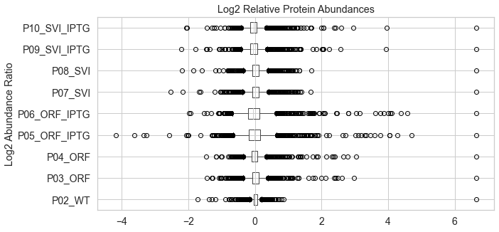

```python
dfP.boxplot(figsize=(10,5), vert=False, fontsize=14)
plt.title('Log2 Relative Protein Abundances')
plt.ylabel('Log2 Abundance Ratio', fontsize='medium')
```

```python
dfP.median()
```

```
P02_WT          0.018634
P03_ORF         0.017209
P04_ORF        -0.018878
P05_ORF_IPTG   -0.013043
P06_ORF_IPTG   -0.054392
P07_SVI         0.007196
P08_SVI         0.001442
P09_SVI_IPTG   -0.046921
P10_SVI_IPTG   -0.043943
dtype: float64
```

Re-normalize the data set so that the median in each samples equals 0.0

```python
dfP =  dfP - dfP.median()
```

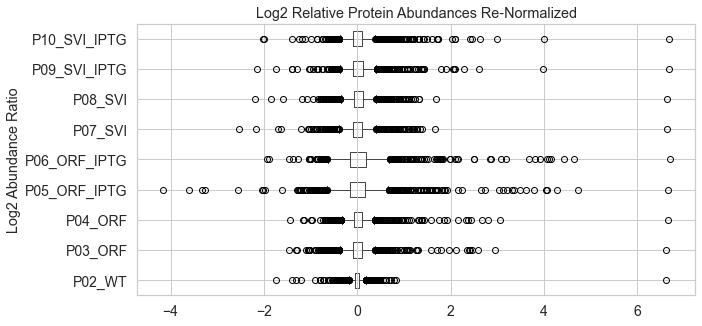

```python
dfP.boxplot(figsize=(10,5), vert=False, fontsize=14)
plt.title('Log2 Relative Protein Abundances Re-Normalized')
plt.ylabel('Log2 Abundance Ratio', fontsize='medium')
```

[output not shown]

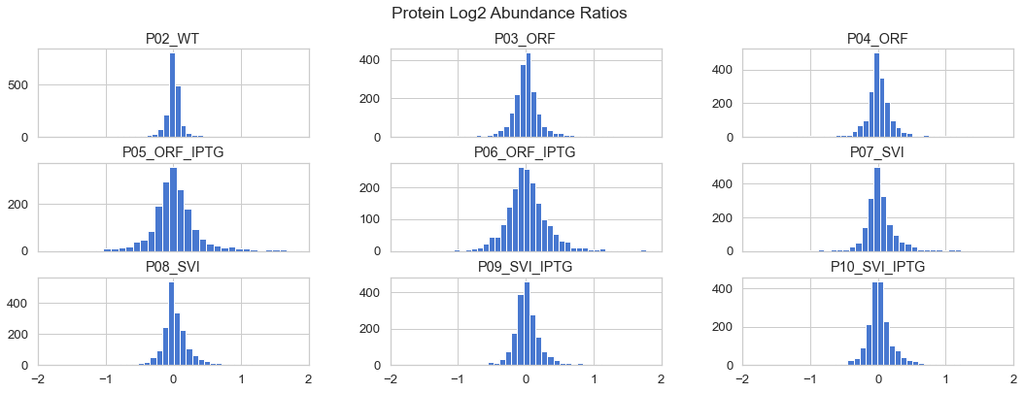

```python
f = dfP.hist(bins=100, sharex=True, figsize=(18,6) )
plt.suptitle('Protein Log2 Abundance Ratios')
plt.xlim(-2, 2)
```

```python
dfP.shape
```

```
(1837, 9)
```

## Let's import the RNA-Seq data

The RNA-Seq data set is [available via the GEO repository](https://www.ncbi.nlm.nih.gov/geo/query/acc.cgi?acc=GSE92601). The RNA-Seq results are represented as RPKM, or reads per kilobase transcript per million reads.

```python
dfRNA = pd.read_csv(
    os.getcwd() + '\\RNA_Data\\GSE92601_Escherichia_coli.Gene.rpkm.txt',
    index_col='Symbol', na_values='-', sep='\t'
)
print(dfRNA.shape)
dfRNA.head(3)
```

```
(4205, 37)
```

| Symbol | GeneID | Length | ORF1_1_mapped_reads(7655775) | ORF1_1_IPTG_mapped_reads(7178582) | ORF1_2_mapped_reads(7706927) | ORF1_2_IPTG_mapped_reads(7070827) | Svi3_3_1_mapped_reads(8018710) | Svi3_3_1_IPTG_mapped_reads(8299205) | Svi3_3_2_mapped_reads(7313736) | Svi3_3_2_IPTG_mapped_reads(8344539) | ... | Svi3_3_1_IPTG_rpkm | Svi3_3_2_rpkm | Svi3_3_2_IPTG_rpkm | WT1_IPTG_rpkm | WT2_IPTG_rpkm | Description | KEGG Orthology | GO Component | GO Function | GO Process |
| --- | --- | --- | --- | --- | --- | --- | --- | --- | --- | --- | --- | --- | --- | --- | --- | --- | --- | --- | --- | --- | --- |
| plaP | b2014 | 1359 | 6788.0 | 3977.0 | 7207.0 | 3875.0 | 1805.0 | 2495.0 | 6703.0 | 5578.0 | ... | 221.215015 | 674.389008 | 491.877214 | 650.883244 | 570.679732 | putrescine importer, low affinity; | K14052\|1\|3e-154\|548\|smaf:D781_1893\|putrescine ... | GO:0005886//plasma membrane;GO:0016021//integr... | GO:0015489//putrescine transmembrane transport... | GO:0048870//cell motility;GO:0003333//amino ac... |
| yniB | b1726 | 537 | 528.0 | 408.0 | 481.0 | 416.0 | 610.0 | 512.0 | 437.0 | 468.0 | ... | 114.883903 | 111.267382 | 104.440566 | 131.462919 | 124.546528 | putative inner membrane protein; | NaN | GO:0005886//plasma membrane;GO:0016021//integr... | NaN | NaN |
| wzc | b2060 | 2163 | 28.0 | 47.0 | 20.0 | 37.0 | 28.0 | 48.0 | 38.0 | 35.0 | ... | 2.673919 | 2.402082 | 1.939140 | 2.633929 | 2.224922 | colanic acid production tyrosine-protein kinas... | K16692\|1\|0.0\|1313\|edj:ECDH1ME8569_1997\|tyrosin... | GO:0016021//integral component of membrane;GO:... | GO:0030234//enzyme regulator activity;GO:00055... | GO:0009103//lipopolysaccharide biosynthetic pr... |

3 rows × 37 columns

```python
print(
    [ (i, c) for i, c in enumerate(dfRNA.columns) ]
)
```

```
[(0, 'GeneID'), (1, 'Length'), (2, 'ORF1_1_mapped_reads(7655775)'), (3, 'ORF1_1_IPTG_mapped_reads(7178582)'), (4, 'ORF1_2_mapped_reads(7706927)'), (5, 'ORF1_2_IPTG_mapped_reads(7070827)'), (6, 'Svi3_3_1_mapped_reads(8018710)'), (7, 'Svi3_3_1_IPTG_mapped_reads(8299205)'), (8, 'Svi3_3_2_mapped_reads(7…
```

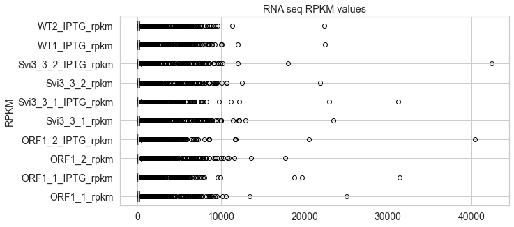

```python
dfRNA.iloc[:, 22:32].replace(0, np.nan).dropna(axis='rows').boxplot(
    figsize=(10,5), vert=False, fontsize=14
)
plt.title('RNA seq RPKM values')
plt.ylabel('RPKM', fontsize='medium')
```

```python
dfRNA.iloc[:, 22:32].replace(0, np.nan).dropna(axis='rows').describe()
```

|  | ORF1_1_rpkm | ORF1_1_IPTG_rpkm | ORF1_2_rpkm | ORF1_2_IPTG_rpkm | Svi3_3_1_rpkm | Svi3_3_1_IPTG_rpkm | Svi3_3_2_rpkm | Svi3_3_2_IPTG_rpkm | WT1_IPTG_rpkm | WT2_IPTG_rpkm |
| --- | --- | --- | --- | --- | --- | --- | --- | --- | --- | --- |
| count | 4131.000000 | 4131.000000 | 4131.000000 | 4131.000000 | 4131.000000 | 4131.000000 | 4131.000000 | 4131.000000 | 4131.000000 | 4131.000000 |
| mean | 291.553740 | 275.922367 | 292.449542 | 273.238331 | 319.817451 | 285.207308 | 304.172649 | 279.671458 | 298.849966 | 300.789132 |
| std | 973.604490 | 991.879055 | 987.554880 | 1037.644534 | 1088.679501 | 1006.739978 | 1016.225724 | 1162.244672 | 981.836937 | 965.417894 |
| min | 0.156619 | 0.313746 | 0.218440 | 0.119046 | 0.214275 | 0.221903 | 0.292156 | 0.271743 | 0.235236 | 0.348581 |
| 25% | 12.581591 | 11.281361 | 10.372300 | 11.446461 | 12.981412 | 12.531025 | 12.573430 | 10.107561 | 12.192065 | 12.836091 |
| 50% | 58.821972 | 56.937451 | 55.046898 | 55.509263 | 58.024019 | 54.222061 | 59.034369 | 47.283358 | 60.259210 | 61.881598 |
| 75% | 183.832323 | 176.882931 | 178.534962 | 173.361900 | 194.219735 | 176.177379 | 187.148790 | 152.025356 | 187.895853 | 194.700291 |
| max | 25029.293040 | 31419.786485 | 17678.495982 | 40426.940296 | 23478.950277 | 31218.302364 | 21885.706897 | 42402.133892 | 22450.270166 | 22354.164069 |

RPKM values are highly skewed, much more so than the proteomic data. Besides, the TMT proteomic data has been represented as abundance ratios towards the abundance in the Sample 1 for each protein. Let's recalculate the RPKM values as ratios to sample 1 as well for consistency.

```python
dfR = dfRNA.iloc[:, 22:32].replace(0, np.nan).dropna(axis='rows').copy()
rnaWT1 = dfR['WT1_IPTG_rpkm'].copy()
dfR = dfR.drop(columns=['WT1_IPTG_rpkm',])
print(dfR.columns)
dfR.head(3)
```

```
Index(['ORF1_1_rpkm', 'ORF1_1_IPTG_rpkm', 'ORF1_2_rpkm', 'ORF1_2_IPTG_rpkm',
       'Svi3_3_1_rpkm', 'Svi3_3_1_IPTG_rpkm', 'Svi3_3_2_rpkm',
       'Svi3_3_2_IPTG_rpkm', 'WT2_IPTG_rpkm'],
      dtype='object')
```

| Symbol | ORF1_1_rpkm | ORF1_1_IPTG_rpkm | ORF1_2_rpkm | ORF1_2_IPTG_rpkm | Svi3_3_1_rpkm | Svi3_3_1_IPTG_rpkm | Svi3_3_2_rpkm | Svi3_3_2_IPTG_rpkm | WT2_IPTG_rpkm |
| --- | --- | --- | --- | --- | --- | --- | --- | --- | --- |
| plaP | 652.428938 | 407.659407 | 688.103584 | 403.257115 | 165.635431 | 221.215015 | 674.389008 | 491.877214 | 570.679732 |
| yniB | 128.431181 | 105.839362 | 116.222321 | 109.559195 | 141.661241 | 114.883903 | 111.267382 | 104.440566 | 124.546528 |
| wzc | 1.690878 | 3.026932 | 1.199754 | 2.419218 | 1.614347 | 2.673919 | 2.402082 | 1.939140 | 2.224922 |

```python
rnaWT1[:3]
```

```
Symbol
plaP    650.883244
yniB    131.462919
wzc       2.633929
Name: WT1_IPTG_rpkm, dtype: float64
```

```python
rnaWT1frame = pd.concat( [rnaWT1.to_frame(),]*9, axis='columns' )
rnaWT1frame.columns = dfR.columns
rnaWT1frame.head(3)
```

| Symbol | ORF1_1_rpkm | ORF1_1_IPTG_rpkm | ORF1_2_rpkm | ORF1_2_IPTG_rpkm | Svi3_3_1_rpkm | Svi3_3_1_IPTG_rpkm | Svi3_3_2_rpkm | Svi3_3_2_IPTG_rpkm | WT2_IPTG_rpkm |
| --- | --- | --- | --- | --- | --- | --- | --- | --- | --- |
| plaP | 650.883244 | 650.883244 | 650.883244 | 650.883244 | 650.883244 | 650.883244 | 650.883244 | 650.883244 | 650.883244 |
| yniB | 131.462919 | 131.462919 | 131.462919 | 131.462919 | 131.462919 | 131.462919 | 131.462919 | 131.462919 | 131.462919 |
| wzc | 2.633929 | 2.633929 | 2.633929 | 2.633929 | 2.633929 | 2.633929 | 2.633929 | 2.633929 | 2.633929 |

```python
dfR = dfR.div(rnaWT1frame, axis='columns')
dfR.head(3)
```

| Symbol | ORF1_1_rpkm | ORF1_1_IPTG_rpkm | ORF1_2_rpkm | ORF1_2_IPTG_rpkm | Svi3_3_1_rpkm | Svi3_3_1_IPTG_rpkm | Svi3_3_2_rpkm | Svi3_3_2_IPTG_rpkm | WT2_IPTG_rpkm |
| --- | --- | --- | --- | --- | --- | --- | --- | --- | --- |
| plaP | 1.002375 | 0.626317 | 1.057184 | 0.619554 | 0.254478 | 0.339869 | 1.036114 | 0.755707 | 0.876777 |
| yniB | 0.976938 | 0.805089 | 0.884069 | 0.833385 | 1.077576 | 0.873888 | 0.846378 | 0.794449 | 0.947389 |
| wzc | 0.641961 | 1.149208 | 0.455500 | 0.918483 | 0.612905 | 1.015183 | 0.911977 | 0.736216 | 0.844716 |

Let's log2-transform the RNA ratios to bring it closer to the proteomic data.

```python
dfR = np.log2(dfR)
dfR.head(3)
```

| Symbol | ORF1_1_rpkm | ORF1_1_IPTG_rpkm | ORF1_2_rpkm | ORF1_2_IPTG_rpkm | Svi3_3_1_rpkm | Svi3_3_1_IPTG_rpkm | Svi3_3_2_rpkm | Svi3_3_2_IPTG_rpkm | WT2_IPTG_rpkm |
| --- | --- | --- | --- | --- | --- | --- | --- | --- | --- |
| plaP | 0.003422 | -0.675034 | 0.080227 | -0.690699 | -1.974387 | -1.556949 | 0.051182 | -0.404101 | -0.189717 |
| yniB | -0.033660 | -0.312780 | -0.177769 | -0.262945 | 0.107789 | -0.194479 | -0.240625 | -0.331974 | -0.077971 |
| wzc | -0.639443 | 0.200640 | -1.134478 | -0.122676 | -0.706265 | 0.021739 | -0.132931 | -0.441799 | -0.243462 |

```python
dfR[dfR.index.duplicated(keep=False)]
```

| Symbol | ORF1_1_rpkm | ORF1_1_IPTG_rpkm | ORF1_2_rpkm | ORF1_2_IPTG_rpkm | Svi3_3_1_rpkm | Svi3_3_1_IPTG_rpkm | Svi3_3_2_rpkm | Svi3_3_2_IPTG_rpkm | WT2_IPTG_rpkm |
| --- | --- | --- | --- | --- | --- | --- | --- | --- | --- |
| insB1 | -0.271160 | -0.364723 | -0.517806 | -0.113422 | 0.125419 | -0.549336 | -0.494726 | -0.581857 | -0.005302 |
| insA | 0.345580 | 0.640064 | 0.118382 | 0.173946 | 0.623587 | 0.257725 | -0.399446 | -0.314035 | -0.094939 |
| insB1 | -0.163344 | -0.239933 | 0.159853 | -0.322669 | -0.289872 | -0.380698 | -0.280058 | -0.111651 | 0.071831 |
| insA | 2.398692 | 0.432648 | 1.552583 | 0.869505 | 1.009942 | 0.960339 | 2.344337 | 1.630552 | 0.257732 |
| insH1 | 0.076764 | -0.007265 | 0.121604 | 0.105703 | 0.438785 | 0.067254 | -0.470273 | -0.660497 | 0.381721 |
| insH1 | -0.583750 | -0.052779 | 0.052359 | -0.048237 | -0.229729 | -0.504624 | -0.565116 | -0.596141 | -0.642732 |

The RNA dataframe contains 3 duplicated gene symbols. Let's remove the duplicates, keeping the first occurrence.

```python
dfR = dfR.loc[ dfR.index.drop_duplicates(keep=False),: ].append( dfR[dfR.index.duplicated(keep='last')] )
dfR.shape
```

```
(4128, 9)
```

```python
dfR.rename(columns= {'ORF1_1_rpkm': 'R03_ORF', 'ORF1_1_IPTG_rpkm': 'R05_ORF_IPTG',
                     'ORF1_2_rpkm': 'R04_ORF', 'ORF1_2_IPTG_rpkm': 'R06_ORF_IPTG',
                     'Svi3_3_1_rpkm': 'R07_SVI', 'Svi3_3_1_IPTG_rpkm': 'R09_SVI_IPTG',
                     'Svi3_3_2_rpkm': 'R08_SVI', 'Svi3_3_2_IPTG_rpkm': 'R10_SVI_IPTG',
                     'WT2_IPTG_rpkm': 'R02_WT'},
           inplace=True)
dfR = dfR[
    ['R02_WT', 'R03_ORF', 'R04_ORF', 'R05_ORF_IPTG', 'R06_ORF_IPTG',
           'R07_SVI', 'R08_SVI', 'R09_SVI_IPTG', 'R10_SVI_IPTG']
]
dfR.head(3)
```

| Symbol | R02_WT | R03_ORF | R04_ORF | R05_ORF_IPTG | R06_ORF_IPTG | R07_SVI | R08_SVI | R09_SVI_IPTG | R10_SVI_IPTG |
| --- | --- | --- | --- | --- | --- | --- | --- | --- | --- |
| plaP | -0.189717 | 0.003422 | 0.080227 | -0.675034 | -0.690699 | -1.974387 | 0.051182 | -1.556949 | -0.404101 |
| yniB | -0.077971 | -0.033660 | -0.177769 | -0.312780 | -0.262945 | 0.107789 | -0.240625 | -0.194479 | -0.331974 |
| wzc | -0.243462 | -0.639443 | -1.134478 | 0.200640 | -0.122676 | -0.706265 | -0.132931 | 0.021739 | -0.441799 |

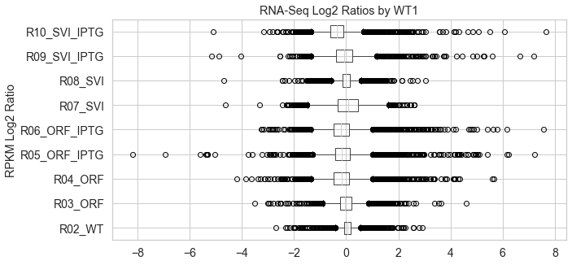

```python
dfR.boxplot(figsize=(10,5), vert=False, fontsize=14)
plt.title('RNA-Seq Log2 Ratios by WT1')
plt.ylabel('RPKM Log2 Ratio', fontsize='medium')
```

```python
dfR.median()
```

```
R02_WT          0.050971
R03_ORF        -0.035602
R04_ORF        -0.163966
R05_ORF_IPTG   -0.153233
R06_ORF_IPTG   -0.189146
R07_SVI         0.096881
R08_SVI         0.003275
R09_SVI_IPTG   -0.084455
R10_SVI_IPTG   -0.343010
dtype: float64
```

Re-normalize the data set so that the median in each samples equals 0.0

```python
dfR =  dfR - dfR.median()
```

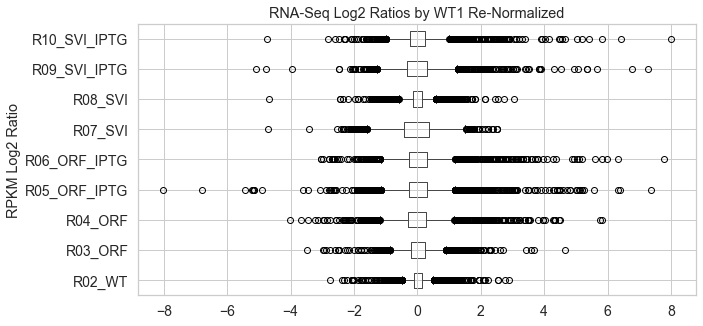

```python
dfR.boxplot(figsize=(10,5), vert=False, fontsize=14)
plt.title('RNA-Seq Log2 Ratios by WT1 Re-Normalized')
plt.ylabel('RPKM Log2 Ratio', fontsize='medium')
```

[output not shown]

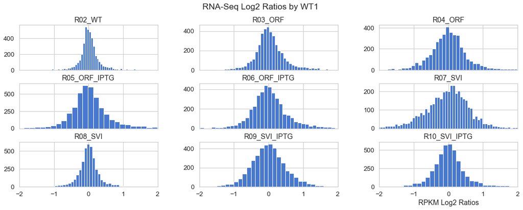

```python
dfR.hist(bins=100, sharex=True, figsize=(18,6) )
plt.suptitle('RNA-Seq Log2 Ratios by WT1')
plt.xlabel('RPKM Log2 Ratios', fontsize='medium')
plt.xlim(-2, 2)
```

Let's look at the genes that are present in both datasets, look at the correlations between them

```python
dfIntersection = dfP.join(dfR, how='inner')
print(dfIntersection.shape)
dfIntersection.head(3)
```

```
(1778, 18)
```

|  | P02_WT | P03_ORF | P04_ORF | P05_ORF_IPTG | P06_ORF_IPTG | P07_SVI | P08_SVI | P09_SVI_IPTG | P10_SVI_IPTG | R02_WT | R03_ORF | R04_ORF | R05_ORF_IPTG | R06_ORF_IPTG | R07_SVI | R08_SVI | R09_SVI_IPTG | R10_SVI_IPTG |
| --- | --- | --- | --- | --- | --- | --- | --- | --- | --- | --- | --- | --- | --- | --- | --- | --- | --- | --- |
| bcp | -0.011439 | -0.103410 | 0.000000 | -0.143777 | -0.136605 | -0.039289 | -0.027647 | -0.046958 | -0.103259 | 0.037836 | 0.094055 | 0.250132 | 0.244861 | 0.245521 | 0.035399 | 0.155029 | -0.212042 | -0.098888 |
| add | 0.042105 | 0.008528 | 0.109731 | 0.149234 | 0.081546 | -0.008639 | 0.070321 | 0.085357 | 0.169594 | 0.179162 | -0.505600 | -0.267415 | 0.189921 | -0.176437 | 0.855490 | 0.452156 | 0.813852 | -0.007602 |
| blc | 0.073573 | 0.076351 | 0.178507 | 0.175253 | 0.403758 | 0.135545 | 0.206451 | 0.110424 | 0.195802 | 0.182074 | 0.190822 | -0.323916 | 0.054620 | -0.174460 | 0.705946 | -0.077694 | 0.716372 | -0.114756 |

Let's check the distribution of the relative abundances in the protein and RNA-Seq data sets. This may give more insight into the biological and technical vairabilities.

```python
dfTemp = pd.DataFrame({'P01_WT': [0, ]*len(dfP.index)}, index=dfP.index)
dfP = dfTemp.join(dfP, how='left')
print(dfP.head(3))
dfTemp = pd.DataFrame({'R01_WT': [0, ]*len(dfR.index)}, index=dfR.index)
dfR = dfTemp.join(dfR, how='left')
print(dfR.head(3))
```

```
      P01_WT    P02_WT   P03_ORF   P04_ORF  P05_ORF_IPTG  P06_ORF_IPTG  \
Gene
bcp        0 -0.011439 -0.103410  0.000000     -0.143777     -0.136605
add        0  0.042105  0.008528  0.109731      0.149234      0.081546
blc        0  0.073573  0.076351  0.178507      0.175253      0.403758

       P07_SVI   P08_SVI  P09_SVI_IPTG  P10_SVI_IPTG
Gene
bcp  -0.039289 -0.027647     -0.046958     -0.103259
add  -0.008639  0.070321      0.085357      0.169594
blc   0.135545  0.206451      0.110424      0.195802
        R01_WT    R02_WT   R03_ORF   R04_ORF  R05_ORF_IPTG  R06_ORF_IPTG  \
Symbol
plaP         0 -0.240689  0.039024  0.244193     -0.521801     -0.501553
yniB         0 -0.128942  0.001941 -0.013802     -0.159546     -0.073799
wzc          0 -0.294433 -0.603842 -0.970511      0.353873      0.066471

         R07_SVI   R08_SVI  R09_SVI_IPTG  R10_SVI_IPTG
Symbol
plaP   -2.071268  0.047907     -1.472494     -0.061090
yniB    0.010909 -0.243900     -0.110024      0.011037
wzc    -0.803146 -0.136206      0.106195     -0.098789
```

```python
dfP.head(3)
```

| Gene | P01_WT | P02_WT | P03_ORF | P04_ORF | P05_ORF_IPTG | P06_ORF_IPTG | P07_SVI | P08_SVI | P09_SVI_IPTG | P10_SVI_IPTG |
| --- | --- | --- | --- | --- | --- | --- | --- | --- | --- | --- |
| bcp | 0 | -0.011439 | -0.103410 | 0.000000 | -0.143777 | -0.136605 | -0.039289 | -0.027647 | -0.046958 | -0.103259 |
| add | 0 | 0.042105 | 0.008528 | 0.109731 | 0.149234 | 0.081546 | -0.008639 | 0.070321 | 0.085357 | 0.169594 |
| blc | 0 | 0.073573 | 0.076351 | 0.178507 | 0.175253 | 0.403758 | 0.135545 | 0.206451 | 0.110424 | 0.195802 |

```python
dfR.head(3)
```

| Symbol | R01_WT | R02_WT | R03_ORF | R04_ORF | R05_ORF_IPTG | R06_ORF_IPTG | R07_SVI | R08_SVI | R09_SVI_IPTG | R10_SVI_IPTG |
| --- | --- | --- | --- | --- | --- | --- | --- | --- | --- | --- |
| plaP | 0 | -0.240689 | 0.039024 | 0.244193 | -0.521801 | -0.501553 | -2.071268 | 0.047907 | -1.472494 | -0.061090 |
| yniB | 0 | -0.128942 | 0.001941 | -0.013802 | -0.159546 | -0.073799 | 0.010909 | -0.243900 | -0.110024 | 0.011037 |
| wzc | 0 | -0.294433 | -0.603842 | -0.970511 | 0.353873 | 0.066471 | -0.803146 | -0.136206 | 0.106195 | -0.098789 |

### Calculate max Log2 FC between the average Log2 abundances per condition

Each condition has been prepared in two parallel bacterial culture, giving two biological replicates per condition. Let's calculate the mean between the replicates for each protein and condition.

```python
def max_LogFC_avg_groups(inDF):
    #Biological replicates are selected by indices
    replArrays = [ inDF.iloc[:,:2], inDF.iloc[:,2:4], inDF.iloc[:,4:6],
                  inDF.iloc[:,6:8], inDF.iloc[:,8:10] ]
    for a in replArrays:
        print(a.columns)

    logMeanArrays = [ np.mean(a, axis=1) for a in replArrays ]

    outDF = pd.DataFrame(logMeanArrays)
    outDF = outDF.transpose()
    outDF.columns = ['WT', 'ORF', 'ORFIPTG', 'SVI', 'SVIPTG']
    outDF.index = inDF.index
    #print(outDF.head(3))
    # Absolute difference between the Log-values here gives the LogFC between replicates
    maxLogFC = lambda row: max(row) - min(row)
    outDF['MaxLog2AVGFC'] = [ maxLogFC(row) for _, row in outDF.iterrows() ]

    return outDF
```

```python
dfP_AVG = max_LogFC_avg_groups(dfP)
print(dfP_AVG.head(3))
dfR_AVG = max_LogFC_avg_groups(dfR)
print(dfR_AVG.head(3))
```

```
Index(['P01_WT', 'P02_WT'], dtype='object')
Index(['P03_ORF', 'P04_ORF'], dtype='object')
Index(['P05_ORF_IPTG', 'P06_ORF_IPTG'], dtype='object')
Index(['P07_SVI', 'P08_SVI'], dtype='object')
Index(['P09_SVI_IPTG', 'P10_SVI_IPTG'], dtype='object')
            WT       ORF   ORFIPTG       SVI    SVIPTG  MaxLog2AVGFC
Gene
bcp  -0.005719 -0.051705 -0.140191 -0.033468 -0.075108      0.134472
add   0.021052  0.059130  0.115390  0.030841  0.127476      0.106423
blc   0.036787  0.127429  0.289505  0.170998  0.153113      0.252719
Index(['R01_WT', 'R02_WT'], dtype='object')
Index(['R03_ORF', 'R04_ORF'], dtype='object')
Index(['R05_ORF_IPTG', 'R06_ORF_IPTG'], dtype='object')
Index(['R07_SVI', 'R08_SVI'], dtype='object')
Index(['R09_SVI_IPTG', 'R10_SVI_IPTG'], dtype='object')
              WT       ORF   ORFIPTG       SVI    SVIPTG  MaxLog2AVGFC
Symbol
plaP   -0.120344  0.141608 -0.511677 -1.011680 -0.766792      1.153289
yniB   -0.064471 -0.005931 -0.116673 -0.116496 -0.049494      0.110742
wzc    -0.147216 -0.787177  0.210172 -0.469676  0.003703      0.997349
```

```python
dfP_AVG = dfP.join(dfP_AVG, how='left')
dfP_AVG.head(3)
```

| Gene | P01_WT | P02_WT | P03_ORF | P04_ORF | P05_ORF_IPTG | P06_ORF_IPTG | P07_SVI | P08_SVI | P09_SVI_IPTG | P10_SVI_IPTG | WT | ORF | ORFIPTG | SVI | SVIPTG | MaxLog2AVGFC |
| --- | --- | --- | --- | --- | --- | --- | --- | --- | --- | --- | --- | --- | --- | --- | --- | --- |
| bcp | 0 | -0.011439 | -0.103410 | 0.000000 | -0.143777 | -0.136605 | -0.039289 | -0.027647 | -0.046958 | -0.103259 | -0.005719 | -0.051705 | -0.140191 | -0.033468 | -0.075108 | 0.134472 |
| add | 0 | 0.042105 | 0.008528 | 0.109731 | 0.149234 | 0.081546 | -0.008639 | 0.070321 | 0.085357 | 0.169594 | 0.021052 | 0.059130 | 0.115390 | 0.030841 | 0.127476 | 0.106423 |
| blc | 0 | 0.073573 | 0.076351 | 0.178507 | 0.175253 | 0.403758 | 0.135545 | 0.206451 | 0.110424 | 0.195802 | 0.036787 | 0.127429 | 0.289505 | 0.170998 | 0.153113 | 0.252719 |

```python
dfR_AVG = dfR.join(dfR_AVG, how='left')
dfR_AVG.head(3)
```

| Symbol | R01_WT | R02_WT | R03_ORF | R04_ORF | R05_ORF_IPTG | R06_ORF_IPTG | R07_SVI | R08_SVI | R09_SVI_IPTG | R10_SVI_IPTG | WT | ORF | ORFIPTG | SVI | SVIPTG | MaxLog2AVGFC |
| --- | --- | --- | --- | --- | --- | --- | --- | --- | --- | --- | --- | --- | --- | --- | --- | --- |
| plaP | 0 | -0.240689 | 0.039024 | 0.244193 | -0.521801 | -0.501553 | -2.071268 | 0.047907 | -1.472494 | -0.061090 | -0.120344 | 0.141608 | -0.511677 | -1.011680 | -0.766792 | 1.153289 |
| yniB | 0 | -0.128942 | 0.001941 | -0.013802 | -0.159546 | -0.073799 | 0.010909 | -0.243900 | -0.110024 | 0.011037 | -0.064471 | -0.005931 | -0.116673 | -0.116496 | -0.049494 | 0.110742 |
| wzc | 0 | -0.294433 | -0.603842 | -0.970511 | 0.353873 | 0.066471 | -0.803146 | -0.136206 | 0.106195 | -0.098789 | -0.147216 | -0.787177 | 0.210172 | -0.469676 | 0.003703 | 0.997349 |

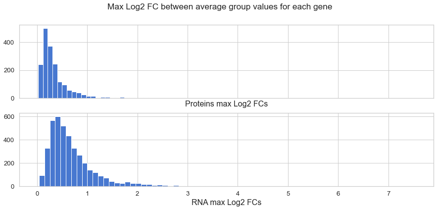

```python
fig, (ax1, ax2) = plt.subplots(nrows=2, sharex=True)#, gridspec_kw={'hspace': 0} )
fig.suptitle('Max Log2 FC between average group values for each gene')
fig.set_figheight(6)
fig.set_figwidth(15)
ax1.hist(x=dfP_AVG['MaxLog2AVGFC'], bins=50)
ax2.hist(x=dfR_AVG['MaxLog2AVGFC'], bins=70)

ax1.set_xlabel('Proteins max Log2 FCs', fontsize=16)
ax2.set_xlabel('RNA max Log2 FCs', fontsize=16)
```

### Let's look at the LogFC between the values for biological replicates in the proteomic and RNA-Seq data

```python
def replicate_LogFC(inDF):
    replArrays = [ inDF.iloc[:,:2], inDF.iloc[:,2:4], inDF.iloc[:,4:6],
                  inDF.iloc[:,6:8], inDF.iloc[:,8:10] ]
    for a in replArrays:
        print(a.columns)
    concatArr = np.concatenate( replArrays, axis=0 )
    print('Concatenated array dimensions:', concatArr.shape)
    # Absolute difference between the Log-values here gives the LogFC between replicates
    diffArray = np.abs(concatArr[:,:1] - concatArr[:,1:])
    return diffArray.reshape(1, -1)[0]
```

```python
protReplLogFC = replicate_LogFC(dfP)
print(protReplLogFC)
print('Proteomics Log2 FC between biological replicates for each gene\n', stats.describe(protReplLogFC), '\n' )
rnaReplLogFC = replicate_LogFC(dfR)
print(rnaReplLogFC)
print('RNA Log2 FC between biological replicates for each gene\n', stats.describe(rnaReplLogFC), '\n' )
```

```
Index(['P01_WT', 'P02_WT'], dtype='object')
Index(['P03_ORF', 'P04_ORF'], dtype='object')
Index(['P05_ORF_IPTG', 'P06_ORF_IPTG'], dtype='object')
Index(['P07_SVI', 'P08_SVI'], dtype='object')
Index(['P09_SVI_IPTG', 'P10_SVI_IPTG'], dtype='object')
Concatenated array dimensions: (9185, 2)
[0.01143867 0.04210498 0.07357326 ... 0.01425267 0.10258095 0.00838106]
Proteomics Log2 FC between biological replicates for each gene
 DescribeResult(nobs=9185, minmax=(0.0, 6.625222015635673), mean=0.11875369510524132, variance=0.03389769684439531, skewness=10.222731115752815, kurtosis=237.2370213614442)

Index(['R01_WT', 'R02_WT'], dtype='object')
Index(['R03_ORF', 'R04_ORF'], dtype='object')
Index(['R05_ORF_IPTG', 'R06_ORF_IPTG'], dtype='object')
Index(['R07_SVI', 'R08_SVI'], dtype='object')
Index(['R09_SVI_IPTG', 'R10_SVI_IPTG'], dtype='object')
Concatenated array dimensions: (20640, 2)
[0.24068853 0.12894221 0.29443288 ... 0.22603376 0.31320507 0.46919626]
RNA Log2 FC between biological replicates for each gene
 DescribeResult(nobs=20640, minmax=(5.895488130742976e-06, 6.642319208232895), mean=0.37757277129653594, variance=0.17092159599274642, skewness=2.7810663958479855, kurtosis=14.581274384957986)
```

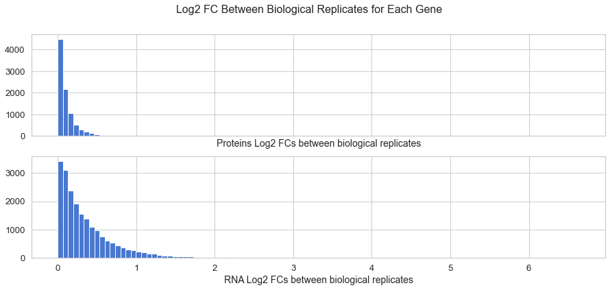

```python
fig, (ax1, ax2) = plt.subplots(nrows=2, sharex=True)#, gridspec_kw={'hspace': 0} )
fig.suptitle('Log2 FC Between Biological Replicates for Each Gene', fontsize=16)
fig.set_figheight(6)
fig.set_figwidth(15)
ax1.hist(x=protReplLogFC, bins=100)
ax2.hist(x=rnaReplLogFC, bins=100)
ax1.set_xlabel('Proteins Log2 FCs between biological replicates', fontsize=14)
ax2.set_xlabel('RNA Log2 FCs between biological replicates', fontsize=14)
```

The replicates are much closer to each other in the proteomic data set.  
In this case, the RNA-Seq quantifies much more genes than proteomics does, but the variability of measurement in the RNAseq is much higher.

```python
pd.DataFrame({'Protein_Repl_Log2FC': protReplLogFC}).describe()
```

|  | Protein_Repl_Log2FC |
| --- | --- |
| count | 9185.000000 |
| mean | 0.118754 |
| std | 0.184113 |
| min | 0.000000 |
| 25% | 0.029104 |
| 50% | 0.069172 |
| 75% | 0.143641 |
| max | 6.625222 |

```python
pd.DataFrame({'RNA_Repl_Log2FC': rnaReplLogFC}).describe()
```

|  | RNA_Repl_Log2FC |
| --- | --- |
| count | 20640.000000 |
| mean | 0.377573 |
| std | 0.413427 |
| min | 0.000006 |
| 25% | 0.102593 |
| 50% | 0.248973 |
| 75% | 0.507566 |
| max | 6.642319 |

The 90th percentile of the log2 FC between replicates for the proteomic data set is

```python
np.percentile(protReplLogFC, 90)
```

```
0.2658608755331754
```

Ninety percent of all replicates differ by less than 20%!

```python
np.exp2(np.percentile(protReplLogFC, 90))
```

```
1.2023532958919598
```

In the RNA-Seq data set, the 90th percentile of log2 replicate FC is

```python
np.percentile(rnaReplLogFC, 90)
```

```
0.8764194924938945
```

Ninety percent of all replicates differ by less than 83%, which is much more variation as compared to the proteomic data

```python
np.exp2(np.percentile(rnaReplLogFC, 90))
```

```
1.8358134865836333
```

Let's join the data frames and select the genes that have a "strong" change in at least one of the cases (protein or RNA)

```python
dfPandR = dfP_AVG.join(dfR_AVG, lsuffix='_Pr', rsuffix='_RNA', how='inner')
print(dfPandR.shape)
dfPandR = dfPandR.loc[
    ( dfPandR['MaxLog2AVGFC_Pr'] >= np.percentile(protReplLogFC, 90) ) |
    ( dfPandR['MaxLog2AVGFC_RNA'] >= np.percentile(rnaReplLogFC, 90) )
].copy()
print(dfPandR.shape)
dfPandR.head(3)
```

```
(1778, 32)
(951, 32)
```

|  | P01_WT | P02_WT | P03_ORF | P04_ORF | P05_ORF_IPTG | P06_ORF_IPTG | P07_SVI | P08_SVI | P09_SVI_IPTG | P10_SVI_IPTG | ... | R07_SVI | R08_SVI | R09_SVI_IPTG | R10_SVI_IPTG | WT_RNA | ORF_RNA | ORFIPTG_RNA | SVI_RNA | SVIPTG_RNA | MaxLog2AVGFC_RNA |
| --- | --- | --- | --- | --- | --- | --- | --- | --- | --- | --- | --- | --- | --- | --- | --- | --- | --- | --- | --- | --- | --- |
| add | 0 | 0.042105 | 0.008528 | 0.109731 | 0.149234 | 0.081546 | -0.008639 | 0.070321 | 0.085357 | 0.169594 | ... | 0.855490 | 0.452156 | 0.813852 | -0.007602 | 0.089581 | -0.386508 | 0.006742 | 0.653823 | 0.403125 | 1.040330 |
| ygaU | 0 | -0.121781 | -0.177250 | 0.124556 | 0.122738 | 0.562314 | 0.436411 | 0.543538 | 0.445271 | 0.551865 | ... | 0.581138 | 0.040330 | 0.757032 | -0.662974 | 0.102870 | -0.337298 | 0.105700 | 0.310734 | 0.047029 | 0.648032 |
| hisP | 0 | 0.004266 | 0.155278 | 0.348863 | -0.276784 | -0.097611 | -0.201490 | -0.137504 | -0.202901 | -0.060754 | ... | 0.107171 | 0.072923 | -0.169629 | -0.179744 | 0.054810 | -0.032549 | -0.692207 | 0.090047 | -0.174687 | 0.782253 |

3 rows × 32 columns

```python
#dfPandR.to_csv('Proteins_RNA_StrongChanges_201015.txt', sep='\t')
```

### Do UMAP embeddings

```python
dfPandR.iloc[:,10:15].head(3)
```

|  | WT_Pr | ORF_Pr | ORFIPTG_Pr | SVI_Pr | SVIPTG_Pr |
| --- | --- | --- | --- | --- | --- |
| add | 0.021052 | 0.059130 | 0.115390 | 0.030841 | 0.127476 |
| ygaU | -0.060891 | -0.026347 | 0.342526 | 0.489975 | 0.498568 |
| hisP | 0.002133 | 0.252070 | -0.187198 | -0.169497 | -0.131828 |

```python
dfPandR.iloc[:,11:15].head(3)
```

|  | ORF_Pr | ORFIPTG_Pr | SVI_Pr | SVIPTG_Pr |
| --- | --- | --- | --- | --- |
| add | 0.059130 | 0.115390 | 0.030841 | 0.127476 |
| ygaU | -0.026347 | 0.342526 | 0.489975 | 0.498568 |
| hisP | 0.252070 | -0.187198 | -0.169497 | -0.131828 |

```python
dfPandR.iloc[:,26:31].head(3)
```

|  | WT_RNA | ORF_RNA | ORFIPTG_RNA | SVI_RNA | SVIPTG_RNA |
| --- | --- | --- | --- | --- | --- |
| add | 0.089581 | -0.386508 | 0.006742 | 0.653823 | 0.403125 |
| ygaU | 0.102870 | -0.337298 | 0.105700 | 0.310734 | 0.047029 |
| hisP | 0.054810 | -0.032549 | -0.692207 | 0.090047 | -0.174687 |

```python
dfPandR.iloc[:,27:31].head(3)
```

|  | ORF_RNA | ORFIPTG_RNA | SVI_RNA | SVIPTG_RNA |
| --- | --- | --- | --- | --- |
| add | -0.386508 | 0.006742 | 0.653823 | 0.403125 |
| ygaU | -0.337298 | 0.105700 | 0.310734 | 0.047029 |
| hisP | -0.032549 | -0.692207 | 0.090047 | -0.174687 |

Do not use the WT values for the embeddings, since, by design, the WT values are close to 0 in this representation of the data. Adding the WT columns most likely will introduce noise and not much else.

```
UMAP(min_dist=0.01, n_epochs=5000, n_neighbors=30, verbose=2)
Construct fuzzy simplicial set
Wed Jan 27 11:25:15 2021 Finding Nearest Neighbors
Wed Jan 27 11:25:15 2021 Finished Nearest Neighbor Search
Wed Jan 27 11:25:15 2021 Construct embedding
	completed  0  /  5000 epochs
	completed  500  /  5000 epochs
	completed  1000  /  5000 epochs
	completed  1500  /  5000 epochs
	completed  2000  /  5000 epochs
	completed  2500  /  5000 epochs
	completed  3000  /  5000 epochs
	completed  3500  /  5000 epochs
	completed  4000  /  5000 epochs
	completed  4500  /  5000 epochs
Wed Jan 27 11:25:22 2021 Finished embedding
```

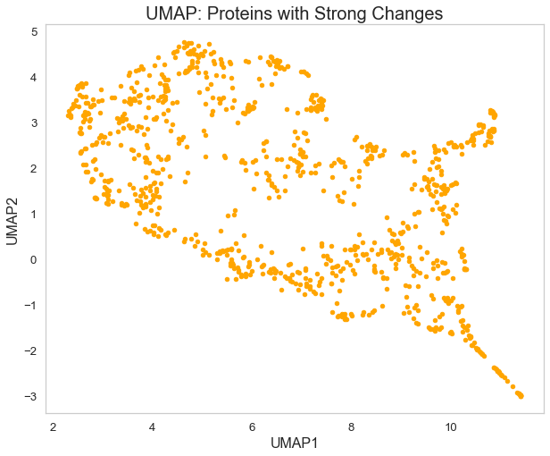

```python
umapModel = umap.UMAP(n_components = 2, min_dist = 0.01, n_neighbors = 30, n_epochs = 5000, verbose = 2)
#Fit the averaged values ORF_Pr, ORFIPTG_Pr, SVI_Pr, SVIPTG_P
umapProt = umapModel.fit_transform(dfPandR.iloc[:,11:15].to_numpy())

plt.figure(figsize = (10,8))
plt.scatter(umapProt[:, 0], umapProt[:, 1], c = 'orange', s = 20)
plt.title('UMAP: Proteins with Strong Changes', fontsize = 20)
plt.grid(b=None)
plt.xlabel('UMAP1', fontsize = 16)
plt.ylabel('UMAP2', fontsize = 16)
```

```python
pd.DataFrame(
    umapProt, columns=['UMAP1','UMAP2'],
    index=dfPandR.index
).to_csv(
    'Proteins_UMAP_Saved_210127.txt',
    sep='\t'
)
```

```
UMAP(min_dist=0.01, n_epochs=5000, n_neighbors=30, verbose=2)
Construct fuzzy simplicial set
Wed Jan 27 11:25:41 2021 Finding Nearest Neighbors
Wed Jan 27 11:25:41 2021 Finished Nearest Neighbor Search
Wed Jan 27 11:25:41 2021 Construct embedding
	completed  0  /  5000 epochs
	completed  500  /  5000 epochs
	completed  1000  /  5000 epochs
	completed  1500  /  5000 epochs
	completed  2000  /  5000 epochs
	completed  2500  /  5000 epochs
	completed  3000  /  5000 epochs
	completed  3500  /  5000 epochs
	completed  4000  /  5000 epochs
	completed  4500  /  5000 epochs
Wed Jan 27 11:25:48 2021 Finished embedding
```

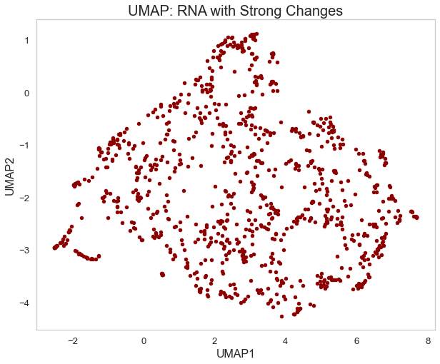

```python
#Fit averaged values ORF_RNA, ORFIPTG_RNA, SVI_RNA, SVIPTG_RNA
umapRNA = umapModel.fit_transform(dfPandR.iloc[:,27:31].to_numpy())

plt.figure(figsize = (10,8))
plt.scatter(umapRNA[:, 0], umapRNA[:, 1], c = 'darkred', s = 20)
plt.title('UMAP: RNA with Strong Changes', fontsize = 20)
plt.grid(b=None)
plt.xlabel('UMAP1', fontsize = 16)
plt.ylabel('UMAP2', fontsize = 16)
```

```python
pd.DataFrame(
    umapRNA, columns=['UMAP1','UMAP2'],
    index=dfPandR.index
).to_csv(
    'RNA_UMAP_Saved_210127.txt',
    sep='\t'
)
```

Now let's perform the integrative UMAP embedding as described by Nikolay Oskolkov [in his blog post on this topic](https://towardsdatascience.com/umap-for-data-integration-50b5cfa4cdcd):

[output not shown]

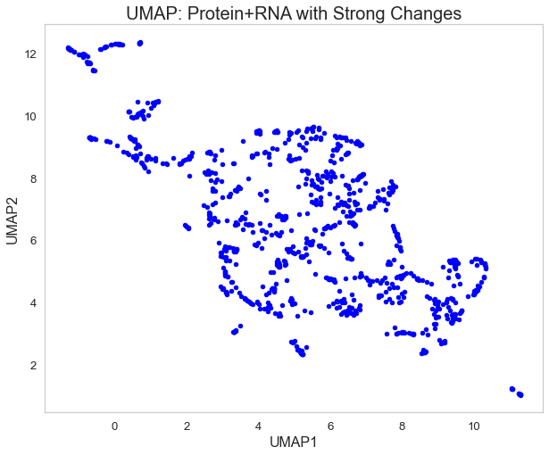

```python
fitP = umapModel.fit(dfPandR.iloc[:,11:15].to_numpy())
fitR = umapModel.fit(dfPandR.iloc[:,27:31].to_numpy())
intersection = umap.umap_.general_simplicial_set_intersection(
    fitP.graph_, fitR.graph_, weight = 0.5
)
intersection = umap.umap_.reset_local_connectivity(intersection)
embedding = umap.umap_.simplicial_set_embedding(
    fitP._raw_data, intersection, fitP.n_components,
    fitP.learning_rate, fitP._a, fitP._b,
    fitP.repulsion_strength, fitP.negative_sample_rate,
    1000, 'random', np.random, fitP.metric,
    fitP._metric_kwds, False
)
plt.figure(figsize = (10,8))
plt.scatter(embedding[:, 0], embedding[:, 1], c = 'blue', s = 20)
plt.title('UMAP: Protein+RNA with Strong Changes', fontsize = 20)
plt.grid(b=None)
plt.xlabel('UMAP1', fontsize = 16)
plt.ylabel('UMAP2', fontsize = 16)
```

```python
dfJointUMAP = pd.DataFrame(embedding, columns=['UMAP1','UMAP2'],
                          index=dfPandR.index)
dfJointUMAP.head(3)
```

|  | UMAP1 | UMAP2 |
| --- | --- | --- |
| add | 10.173355 | 5.370468 |
| ygaU | 6.467403 | 8.807054 |
| hisP | 8.406342 | 4.768059 |

```python
dfJointUMAP.to_csv('Joint_UMAP_Saved_210127.txt', sep='\t')
```

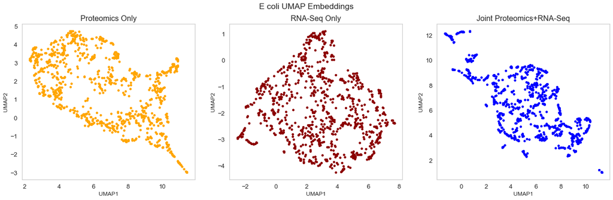

```python
fig, (ax1, ax2, ax3) = plt.subplots(nrows=1, ncols=3, figsize=(22, 6) )
fig.suptitle('E coli UMAP Embeddings')

ax1.scatter(
    umapProt[:, 0], umapProt[:, 1],
    c = 'orange', s = 15
)
ax1.set_title('Proteomics Only', fontsize = 16)
def add_repeated(ax):
    ax.set_xlabel('UMAP1', fontsize = 12)
    ax.set_ylabel('UMAP2', fontsize = 12)
    ax.grid(b=None)
add_repeated(ax1)

ax2.scatter(
    umapRNA[:, 0], umapRNA[:, 1],
    c = 'darkred', s = 15
)
ax2.set_title('RNA-Seq Only', fontsize = 16)
add_repeated(ax2)

ax3.scatter(
    dfJointUMAP['UMAP1'], dfJointUMAP['UMAP2'],
    c = 'blue', s = 15
)
ax3.set_title('Joint Proteomics+RNA-Seq', fontsize = 16)
add_repeated(ax3)
```

### Apply DBSCAN clustering to the UMAP embedding

```
Found clusters 52
```

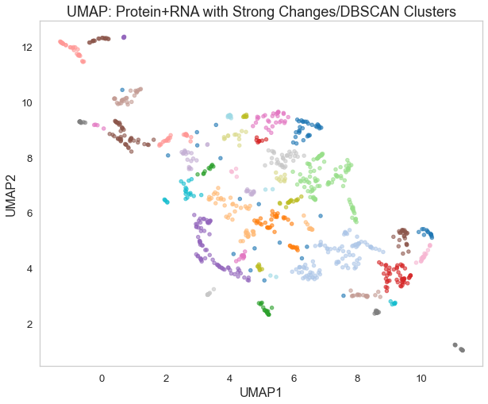

```python
labelsDBSCAN = clustering_dbscan(dfJointUMAP, eps=0.25, min_samples=2)

plt.figure(figsize = (10,8))
plt.scatter(
    dfJointUMAP['UMAP1'], dfJointUMAP['UMAP2'],
    c = labelsDBSCAN, cmap='tab20', alpha=0.6, s = 20
)
plt.title('UMAP: Protein+RNA with Strong Changes/DBSCAN Clusters', fontsize = 18)
plt.grid(b=None)
plt.xlabel('UMAP1', fontsize = 16)
plt.ylabel('UMAP2', fontsize = 16)
```

[output not shown]

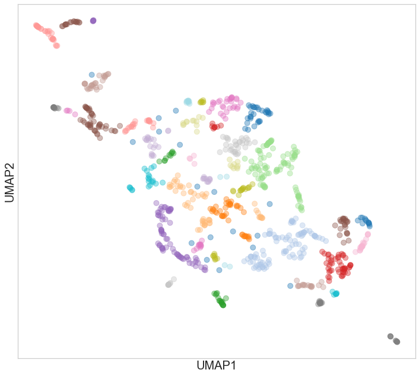

```python
plt.figure(figsize = (12,11))
plt.scatter(
    dfJointUMAP['UMAP1'], dfJointUMAP['UMAP2'],
    c = labelsDBSCAN, s = 80,
    cmap='tab20', alpha=0.4
)
plt.grid(b=None)
plt.xlabel('UMAP1', fontsize = 20)
plt.ylabel('UMAP2', fontsize = 20)
plt.xticks([])
plt.yticks([])
```

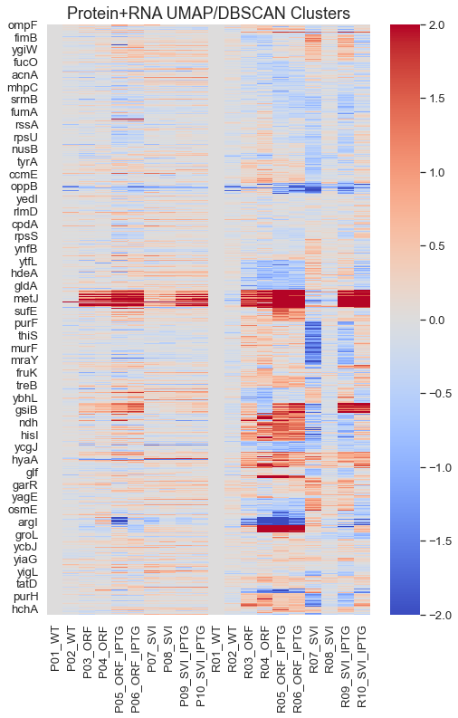

```python
dfDBSCAN = plot_heatmap(
    dfPandR.iloc[:, list(range(0,10)) + list(range(16,26)) ],
    labelsDBSCAN,
    'Protein+RNA UMAP/DBSCAN Clusters'
)
```

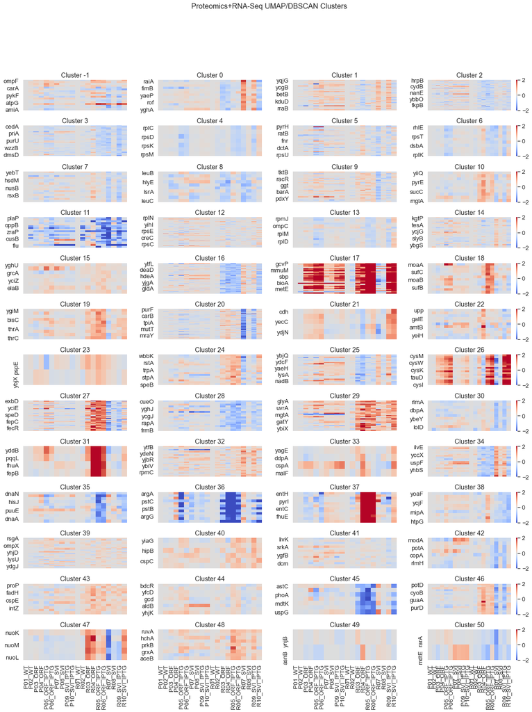

```python
clusterList = sorted( dfDBSCAN['cluster'].unique() )
#for cl in clusterList:
#    print('Cluster #', cl, list( dfDBSCAN[ dfDBSCAN['cluster'] == cl ].index ) )

#Create the grid with a small heatmap corresponding to each cluster
#Set 4 columns, adapt the number of rows to the number of clusters
ncols = 4
nrows = int( np.ceil( len(clusterList) / ncols ) )
f = plt.figure( figsize=(20, 1.8*nrows ) )

grid = plt.GridSpec(nrows, ncols, figure=f, wspace=0.3, hspace=0.5)
plt.suptitle('Proteomics+RNA-Seq UMAP/DBSCAN Clusters', fontsize=16)

xcoord = 0
ycoord = 0
for cl in clusterList:
    plt.subplot(grid[xcoord, ycoord])
    toShowCbar = False
    if ycoord == (ncols-1):
        toShowCbar = True
    toShowXLabels = False
    if xcoord == (nrows-1):
        toShowXLabels = True
    ax = sns.heatmap( dfDBSCAN[ dfDBSCAN['cluster'] == cl].iloc[:, :-1],
                     square=False, cmap='coolwarm', vmin=-2, vmax=2,
                     xticklabels= toShowXLabels,
                     annot=False, cbar=toShowCbar, linewidth=0, linecolor='white')
    ax.set_title(f'Cluster {cl}')
    ycoord += 1
    if ycoord == ncols:
        xcoord += 1
        ycoord = 0
```

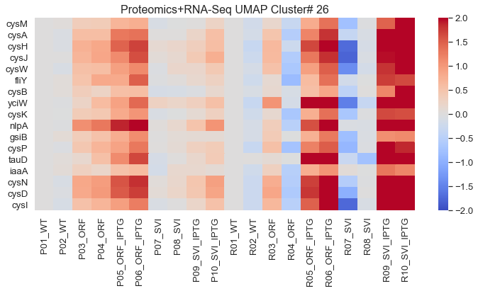

```python
clNum = 26
plt.figure(figsize=(12,5))
sns.heatmap(
    dfDBSCAN[ dfDBSCAN['cluster'] == clNum].iloc[:, :-1],
    cmap='coolwarm', vmin=-2, vmax=2, cbar=True, annot=False
)
plt.title(f'Proteomics+RNA-Seq UMAP Cluster# {clNum}', fontsize = 16)
```

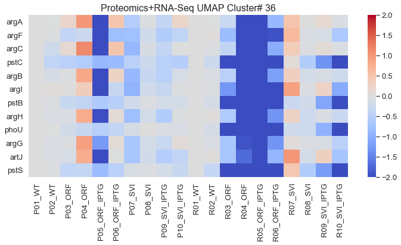

```python
clNum = 36
plt.figure(figsize=(12,5))
sns.heatmap(
    dfDBSCAN[ dfDBSCAN['cluster'] == clNum].iloc[:, :-1],
    cmap='coolwarm', vmin=-2, vmax=2, cbar=True, annot=False
)
plt.title(f'Proteomics+RNA-Seq UMAP Cluster# {clNum}', fontsize = 16)
```

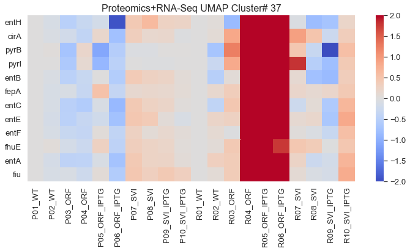

```python
clNum = 37
plt.figure(figsize=(12,5))
sns.heatmap(
    dfDBSCAN[ dfDBSCAN['cluster'] == clNum].iloc[:, :-1],
    cmap='coolwarm', vmin=-2, vmax=2, cbar=True, annot=False
)
plt.title(f'Proteomics+RNA-Seq UMAP Cluster# {clNum}', fontsize = 16)
```

### Apply mean shift clustering to the UMAP embedding

```
Found clusters 43
```

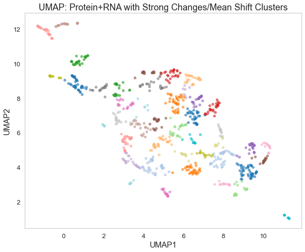

```python
labelsMS = clustering_meanshift(dfJointUMAP, bandwidth=0.55)

plt.figure(figsize = (10,8))
plt.scatter(
    dfJointUMAP['UMAP1'], dfJointUMAP['UMAP2'],
    c = labelsMS, cmap='tab20', alpha=0.6, s = 20
)
plt.title('UMAP: Protein+RNA with Strong Changes/Mean Shift Clusters', fontsize = 18)
plt.grid(b=None)
plt.xlabel('UMAP1', fontsize = 16)
plt.ylabel('UMAP2', fontsize = 16)
```

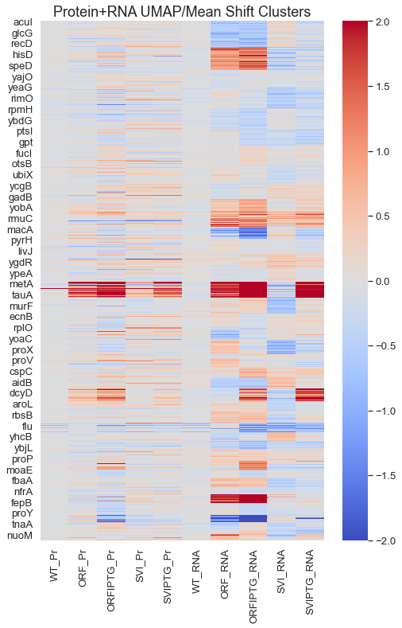

```python
dfMeanShift = plot_heatmap(
    dfPandR.iloc[:, list(range(10,15)) + list(range(26,31)) ],
    labelsMS,
    'Protein+RNA UMAP/Mean Shift Clusters'
)
```

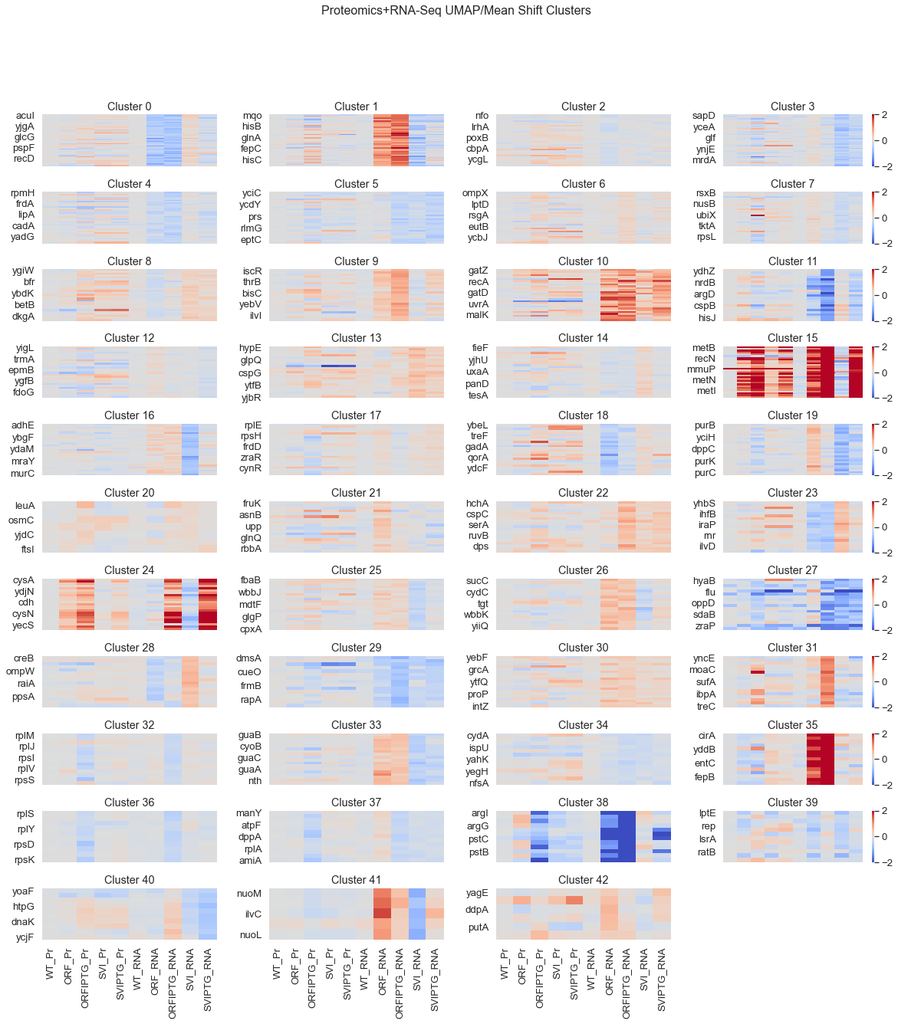

```python
clusterList = sorted( dfMeanShift['cluster'].unique() )
#for cl in clusterList:
#    print('Cluster #', cl, list( dfDBSCAN[ dfDBSCAN['cluster'] == cl ].index ) )

#Create the grid with a small heatmap corresponding to each cluster
#Set 4 columns, adapt the number of rows to the number of clusters
ncols = 4
nrows = int( np.ceil( len(clusterList) / ncols ) )
f = plt.figure( figsize=(20, 1.8*nrows ) )

grid = plt.GridSpec(nrows, ncols, figure=f, wspace=0.3, hspace=0.5)
plt.suptitle('Proteomics+RNA-Seq UMAP/Mean Shift Clusters', fontsize=16)

xcoord = 0
ycoord = 0
for cl in clusterList:
    plt.subplot(grid[xcoord, ycoord])
    toShowCbar = False
    if ycoord == (ncols-1):
        toShowCbar = True
    toShowXLabels = False
    if xcoord == (nrows-1):
        toShowXLabels = True
    ax = sns.heatmap( dfMeanShift[ dfMeanShift['cluster'] == cl].iloc[:, :-1],
                     square=False, cmap='coolwarm', vmin=-2, vmax=2,
                     xticklabels= toShowXLabels,
                     annot=False, cbar=toShowCbar, linewidth=0, linecolor='white')
    ax.set_title(f'Cluster {cl}')
    ycoord += 1
    if ycoord == ncols:
        xcoord += 1
        ycoord = 0
```

### Apply agglomerative clustering to the UMAP embedding

```
Found clusters 45
```

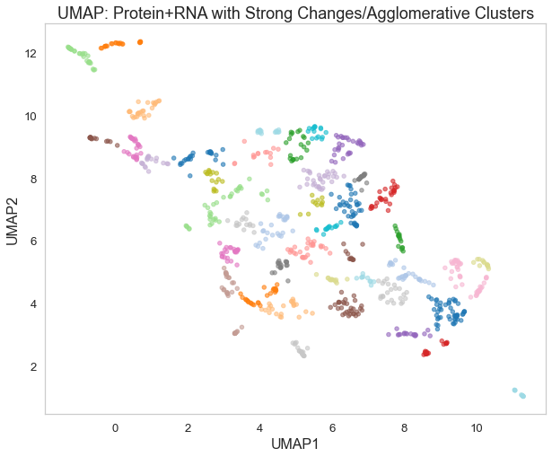

```python
labelsAgglo = clustering_agglo(dfJointUMAP, n_clusters=45)

plt.figure(figsize = (10,8))
plt.scatter(
    dfJointUMAP['UMAP1'], dfJointUMAP['UMAP2'],
    c = labelsAgglo, cmap='tab20', alpha=0.6, s = 20
)
plt.title('UMAP: Protein+RNA with Strong Changes/Agglomerative Clusters', fontsize = 18)
plt.grid(b=None)
plt.xlabel('UMAP1', fontsize = 16)
plt.ylabel('UMAP2', fontsize = 16)
```

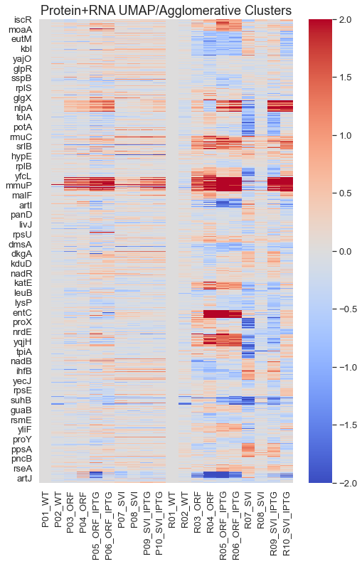

```python
dfClustAggl = plot_heatmap(dfPandR.iloc[:, list(range(0,10)) + list(range(16,26)) ],
                 labelsAgglo,
                 'Protein+RNA UMAP/Agglomerative Clusters')
```

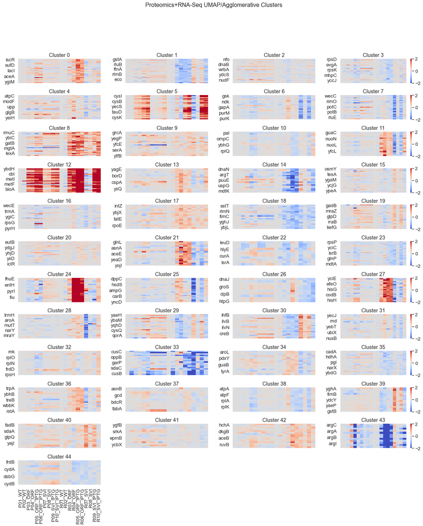

```python
clusterList = sorted( list( set(labelsAgglo) ) )

#Create the grid with a small heatmap corresponding to each cluster
#Set 4 columns, adapt the number of rows to the number of clusters
ncols = 4
nrows = int( np.ceil( len(clusterList) / ncols ) )
f = plt.figure( figsize=(20, 1.8*nrows ) )

grid = plt.GridSpec(nrows, ncols, figure=f, wspace=0.3, hspace=0.5)
plt.suptitle('Proteomics+RNA-Seq UMAP/Agglomerative Clusters', fontsize=16)

#dClustAggl = dfPandR.iloc[:, list(range(10,15)) + list(range(26,31)) ].copy()
#dClustAggl['cluster'] = labelsAgglo

xcoord = 0
ycoord = 0
for cl in clusterList:
    plt.subplot(grid[xcoord, ycoord])
    toShowCbar = False
    if ycoord == (ncols-1):
        toShowCbar = True
    toShowXLabels = False
    if xcoord == (nrows-1):
        toShowXLabels = True
    ax = sns.heatmap( dfClustAggl[ dfClustAggl['cluster'] == cl].iloc[:, :-1],
                     square=False, cmap='coolwarm', vmin=-2, vmax=2,
                     xticklabels= toShowXLabels,
                     annot=False, cbar=toShowCbar, linewidth=0, linecolor='white')
    ax.set_title(f'Cluster {cl}')
    ycoord += 1
    if ycoord == ncols:
        xcoord += 1
        ycoord = 0
```

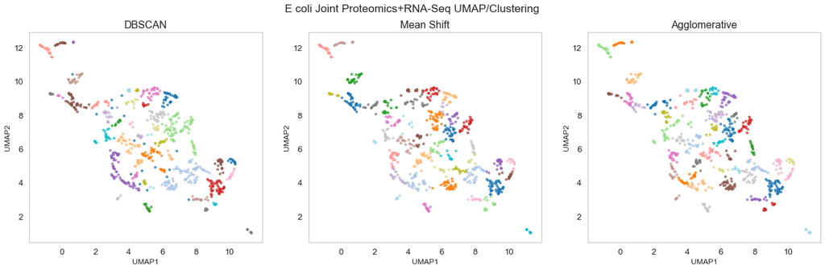

```python
fig, (ax1, ax2, ax3) = plt.subplots(nrows=1, ncols=3, figsize=(22, 6) )
fig.suptitle('E coli Joint Proteomics+RNA-Seq UMAP/Clustering')

ax1.scatter(
    dfJointUMAP['UMAP1'], dfJointUMAP['UMAP2'],
    c = labelsDBSCAN, cmap='tab20', alpha=0.7, s = 10
)
ax1.set_title('DBSCAN', fontsize = 16)
def add_repeated(ax):
    ax.set_xlabel('UMAP1', fontsize = 12)
    ax.set_ylabel('UMAP2', fontsize = 12)
    ax.grid(b=None)
add_repeated(ax1)

ax2.scatter(
    dfJointUMAP['UMAP1'], dfJointUMAP['UMAP2'],
    c = labelsMS, cmap='tab20', alpha=0.7, s = 10
)
ax2.set_title('Mean Shift', fontsize = 16)
add_repeated(ax2)

ax3.scatter(
    dfJointUMAP['UMAP1'], dfJointUMAP['UMAP2'],
    c = labelsAgglo, cmap='tab20', alpha=0.7, s = 10
)
ax3.set_title('Agglomerative', fontsize = 16)
add_repeated(ax3)
```